# Day3: Data wrangling and HPC

2024-08-22

## Today’s goal

We will learn about

- data wrangling with `dplyr`
- run R code on HPC (cluster)

All with the `diamonds` dataset from `ggplot2` package

## What is data wrangling

- Wikipedia: “The process of transforming and mapping data from one”raw” data form into another format with the intent of making it more appropriate and valuable for a variety of downstream purposes such as analytics.”
- Layman: data **transformation** to make it easily accessible and readable.

## Example

```r
library(ggplot2)
data(diamonds)
# A dataset containing the prices and other attributes of ~54000 diamonds
diamonds
```

```
## # A tibble: 53,940 × 10
##    carat cut       color clarity depth table price     x     y     z
##    <dbl> <ord>     <ord> <ord>   <dbl> <dbl> <int> <dbl> <dbl> <dbl>
##  1  0.23 Ideal     E     SI2      61.5    55   326  3.95  3.98  2.43
##  2  0.21 Premium   E     SI1      59.8    61   326  3.89  3.84  2.31
##  3  0.23 Good      E     VS1      56.9    65   327  4.05  4.07  2.31
##  4  0.29 Premium   I     VS2      62.4    58   334  4.2   4.23  2.63
##  5  0.31 Good      J     SI2      63.3    58   335  4.34  4.35  2.75
##  6  0.24 Very Good J     VVS2     62.8    57   336  3.94  3.96  2.48
##  7  0.24 Very Good I     VVS1     62.3    57   336  3.95  3.98  2.47
##  8  0.26 Very Good H     SI1      61.9    55   337  4.07  4.11  2.53
##  9  0.22 Fair      E     VS2      65.1    61   337  3.87  3.78  2.49
## 10  0.23 Very Good H     VS1      59.4    61   338  4     4.05  2.39
## # ℹ 53,930 more rows
```

## Example

```r
glimpse(diamonds)
```

```
## Rows: 53,940
## Columns: 10
## $ carat   <dbl> 0.23, 0.21, 0.23, 0.29, 0.31, 0.24, 0.24, 0.26, 0.22, 0.23, 0.…
## $ cut     <ord> Ideal, Premium, Good, Premium, Good, Very Good, Very Good, Ver…
## $ color   <ord> E, E, E, I, J, J, I, H, E, H, J, J, F, J, E, E, I, J, J, J, I,…
## $ clarity <ord> SI2, SI1, VS1, VS2, SI2, VVS2, VVS1, SI1, VS2, VS1, SI1, VS1, …
## $ depth   <dbl> 61.5, 59.8, 56.9, 62.4, 63.3, 62.8, 62.3, 61.9, 65.1, 59.4, 64…
## $ table   <dbl> 55, 61, 65, 58, 58, 57, 57, 55, 61, 61, 55, 56, 61, 54, 62, 58…
## $ price   <int> 326, 326, 327, 334, 335, 336, 336, 337, 337, 338, 339, 340, 34…
## $ x       <dbl> 3.95, 3.89, 4.05, 4.20, 4.34, 3.94, 3.95, 4.07, 3.87, 4.00, 4.…
## $ y       <dbl> 3.98, 3.84, 4.07, 4.23, 4.35, 3.96, 3.98, 4.11, 3.78, 4.05, 4.…
## $ z       <dbl> 2.43, 2.31, 2.31, 2.63, 2.75, 2.48, 2.47, 2.53, 2.49, 2.39, 2.…
```

## Example: factor variable

```r
summary(diamonds)
```

```
##      carat               cut        color        clarity          depth
##  Min.   :0.2000   Fair     : 1610   D: 6775   SI1    :13065   Min.   :43.00
##  1st Qu.:0.4000   Good     : 4906   E: 9797   VS2    :12258   1st Qu.:61.00
##  Median :0.7000   Very Good:12082   F: 9542   SI2    : 9194   Median :61.80
##  Mean   :0.7979   Premium  :13791   G:11292   VS1    : 8171   Mean   :61.75
##  3rd Qu.:1.0400   Ideal    :21551   H: 8304   VVS2   : 5066   3rd Qu.:62.50
##  Max.   :5.0100                     I: 5422   VVS1   : 3655   Max.   :79.00
##                                     J: 2808   (Other): 2531
##      table           price             x                y
##  Min.   :43.00   Min.   :  326   Min.   : 0.000   Min.   : 0.000
##  1st Qu.:56.00   1st Qu.:  950   1st Qu.: 4.710   1st Qu.: 4.720
##  Median :57.00   Median : 2401   Median : 5.700   Median : 5.710
##  Mean   :57.46   Mean   : 3933   Mean   : 5.731   Mean   : 5.735
##  3rd Qu.:59.00   3rd Qu.: 5324   3rd Qu.: 6.540   3rd Qu.: 6.540
##  Max.   :95.00   Max.   :18823   Max.   :10.740   Max.   :58.900
##
##        z
##  Min.   : 0.000
##  1st Qu.: 2.910
##  Median : 3.530
##  Mean   : 3.539
##  3rd Qu.: 4.040
##  Max.   :31.800
##
```

## The `dplyr` package

Typically we need to explore and prepare data for analysis:

- create summary statistics for variables and individuals.
- individuals that do not meet certain criteria need to be removed.
- create new variables.
- do multiple things at the same time, eg. subsetting, creating, extracting.

`dplyr` provide a clean and nice syntax to perform these!

## Commonly-used `dplyr` functions

“verb” functions in `dplyr`:

- `select()`
- `filter()`
- `mutate()`
- `summarize()`
- `group_by()`

## Installation

```r
library(tidyverse) # automatically load dplyr

# or install dplyr
install.packages("dplyr")
library(dplyr)
```

## select(): subsetting data column wise

- `select()` allows you to select columns (or variables) in a data frame.
- `select(x, y)` means selecting variable `y` from data frame `x`.
- Note: `y` can be a vector of column names or numerical positions in the data frame.

## select(): in action

```r
select(diamonds, carat, price) # extract carat and price
```

```
## # A tibble: 53,940 × 2
##    carat price
##    <dbl> <int>
##  1  0.23   326
##  2  0.21   326
##  3  0.23   327
##  4  0.29   334
##  5  0.31   335
##  6  0.24   336
##  7  0.24   336
##  8  0.26   337
##  9  0.22   337
## 10  0.23   338
## # ℹ 53,930 more rows
```

## Exercise: The 4C’s

Exercise: create a dataframe, `diamonds_4c`, that contains the 4C’s (cut, color, clarity, carat)

```r
diamonds_4c <- ...
```

## Exercise: The 4C’s

```r
diamonds_4c <- select(diamonds, cut, color, clarity, carat)
diamonds_4c
```

```
## # A tibble: 53,940 × 4
##    cut       color clarity carat
##    <ord>     <ord> <ord>   <dbl>
##  1 Ideal     E     SI2      0.23
##  2 Premium   E     SI1      0.21
##  3 Good      E     VS1      0.23
##  4 Premium   I     VS2      0.29
##  5 Good      J     SI2      0.31
##  6 Very Good J     VVS2     0.24
##  7 Very Good I     VVS1     0.24
##  8 Very Good H     SI1      0.26
##  9 Fair      E     VS2      0.22
## 10 Very Good H     VS1      0.23
## # ℹ 53,930 more rows
```

## filter(): subsetting data row wise

- `filter()` allows you to extract rows that meet some logical criteria.
- `filter(x, y)`: extract the rows of `x` where `y` is `TRUE`.

## filter(): in action

```r
filter(diamonds, price <= 2000) # filter diamonds with price under 2000
```

```
## # A tibble: 24,207 × 10
##    carat cut       color clarity depth table price     x     y     z
##    <dbl> <ord>     <ord> <ord>   <dbl> <dbl> <int> <dbl> <dbl> <dbl>
##  1  0.23 Ideal     E     SI2      61.5    55   326  3.95  3.98  2.43
##  2  0.21 Premium   E     SI1      59.8    61   326  3.89  3.84  2.31
##  3  0.23 Good      E     VS1      56.9    65   327  4.05  4.07  2.31
##  4  0.29 Premium   I     VS2      62.4    58   334  4.2   4.23  2.63
##  5  0.31 Good      J     SI2      63.3    58   335  4.34  4.35  2.75
##  6  0.24 Very Good J     VVS2     62.8    57   336  3.94  3.96  2.48
##  7  0.24 Very Good I     VVS1     62.3    57   336  3.95  3.98  2.47
##  8  0.26 Very Good H     SI1      61.9    55   337  4.07  4.11  2.53
##  9  0.22 Fair      E     VS2      65.1    61   337  3.87  3.78  2.49
## 10  0.23 Very Good H     VS1      59.4    61   338  4     4.05  2.39
## # ℹ 24,197 more rows
```

## Exercise: The high roller

Suppose a customer arrives at your store and wants to only look at your “finest” diamonds. Create a data frame `diamonds_fine` that contains all diamonds that are both *ideal* in cut and *internally flawless* (IF) in clarity.

## Exercise: The high roller

```r
diamonds_fine <- filter(diamonds,
                        clarity == "IF" & cut == "Ideal")
diamonds_fine
```

```
## # A tibble: 1,212 × 10
##    carat cut   color clarity depth table price     x     y     z
##    <dbl> <ord> <ord> <ord>   <dbl> <dbl> <int> <dbl> <dbl> <dbl>
##  1  0.52 Ideal F     IF       62.2  55    2783  5.14  5.18  3.21
##  2  0.55 Ideal G     IF       60.9  57    2789  5.28  5.3   3.22
##  3  0.64 Ideal G     IF       61.3  56    2790  5.54  5.58  3.41
##  4  0.61 Ideal G     IF       62.3  56    2800  5.43  5.45  3.39
##  5  0.53 Ideal F     IF       61.9  54    2802  5.22  5.25  3.24
##  6  0.62 Ideal G     IF       60.5  57    2868  5.52  5.56  3.35
##  7  0.62 Ideal G     IF       61.8  56    2869  5.43  5.47  3.37
##  8  0.71 Ideal I     IF       61.5  56    2925  5.74  5.77  3.54
##  9  0.74 Ideal I     IF       62.1  53.9  2952  5.79  5.81  3.6
## 10  0.64 Ideal G     IF       61.7  58    2960  5.52  5.56  3.42
## # ℹ 1,202 more rows
```

## mutate(): change/create a variable

- `mutate(x, y=args)`: add a column `y` to data frame `x`, where `y = args`. If `y` already exists, then replace `y` with `y = args`.
- You can change/create multiple variables using one pass of `mutate()`.

## mutate(): creating a variable

```r
mutate(diamonds_4c,
       carat_squared = carat^2,
       carat_cubed = carat^3)
```

```
## # A tibble: 53,940 × 6
##    cut       color clarity carat carat_squared carat_cubed
##    <ord>     <ord> <ord>   <dbl>         <dbl>       <dbl>
##  1 Ideal     E     SI2      0.23        0.0529     0.0122
##  2 Premium   E     SI1      0.21        0.0441     0.00926
##  3 Good      E     VS1      0.23        0.0529     0.0122
##  4 Premium   I     VS2      0.29        0.0841     0.0244
##  5 Good      J     SI2      0.31        0.0961     0.0298
##  6 Very Good J     VVS2     0.24        0.0576     0.0138
##  7 Very Good I     VVS1     0.24        0.0576     0.0138
##  8 Very Good H     SI1      0.26        0.0676     0.0176
##  9 Fair      E     VS2      0.22        0.0484     0.0106
## 10 Very Good H     VS1      0.23        0.0529     0.0122
## # ℹ 53,930 more rows
```

## mutate(): changing a variable

change a factor variable to numerics

```r
levels(diamonds$clarity) # in order from low to high
```

```
## [1] "I1"   "SI2"  "SI1"  "VS2"  "VS1"  "VVS2" "VVS1" "IF"
```

```r
head(diamonds$clarity)
```

```
## [1] SI2  SI1  VS1  VS2  SI2  VVS2
## Levels: I1 < SI2 < SI1 < VS2 < VS1 < VVS2 < VVS1 < IF
```

```r
head(as.numeric(diamonds$clarity))
```

```
## [1] 2 3 5 4 2 6
```

## mutate(): changing a variable

```r
mutate(diamonds_4c, clarity = as.numeric(clarity))
```

```
## # A tibble: 53,940 × 4
##    cut       color clarity carat
##    <ord>     <ord>   <dbl> <dbl>
##  1 Ideal     E           2  0.23
##  2 Premium   E           3  0.21
##  3 Good      E           5  0.23
##  4 Premium   I           4  0.29
##  5 Good      J           2  0.31
##  6 Very Good J           6  0.24
##  7 Very Good I           7  0.24
##  8 Very Good H           3  0.26
##  9 Fair      E           4  0.22
## 10 Very Good H           5  0.23
## # ℹ 53,930 more rows
```

## Exercise: Lost in (Data) translation

Suppose you have buyer from China. Create a new dataframe `diamonds_rmb` that *replaces* the variable price with `price` in Chinese Yuan.

Hint: 1 USD is equivalent to 7.16 Yuan

## Exercise: Lost in (Data) translation

```r
diamonds_rmb <- mutate(diamonds, price = 7.16 * price)
diamonds_rmb
```

```
## # A tibble: 53,940 × 10
##    carat cut       color clarity depth table price     x     y     z
##    <dbl> <ord>     <ord> <ord>   <dbl> <dbl> <dbl> <dbl> <dbl> <dbl>
##  1  0.23 Ideal     E     SI2      61.5    55 2334.  3.95  3.98  2.43
##  2  0.21 Premium   E     SI1      59.8    61 2334.  3.89  3.84  2.31
##  3  0.23 Good      E     VS1      56.9    65 2341.  4.05  4.07  2.31
##  4  0.29 Premium   I     VS2      62.4    58 2391.  4.2   4.23  2.63
##  5  0.31 Good      J     SI2      63.3    58 2399.  4.34  4.35  2.75
##  6  0.24 Very Good J     VVS2     62.8    57 2406.  3.94  3.96  2.48
##  7  0.24 Very Good I     VVS1     62.3    57 2406.  3.95  3.98  2.47
##  8  0.26 Very Good H     SI1      61.9    55 2413.  4.07  4.11  2.53
##  9  0.22 Fair      E     VS2      65.1    61 2413.  3.87  3.78  2.49
## 10  0.23 Very Good H     VS1      59.4    61 2420.  4     4.05  2.39
## # ℹ 53,930 more rows
```

## summarize(): Summarize the data

- `summarize()` creates a new table of summary statistics (Maps a vector to a scalar).
- `summarize(x, y = f(z))`: Apply `f` to the variable `z` in `x` and call it `y`.
- Some example functions: `sum(z)`, `mean(z)`, `median(z)`, `min(z)`, `max(z)`.
- Allows user-defined functions.
- `summarise()` works as well.

## summarize(): in action

```r
summarize(diamonds, avg_price = mean(price))
```

```
## # A tibble: 1 × 1
##   avg_price
##       <dbl>
## 1     3933.
```

## summarize(): in action

- allows user-defined functions (takes a vector and returns a scalar)

```r
ssq <- function(x){
  return(sum(x^2))
}
summarize(diamonds, ssq_price = ssq(price))
```

```
## # A tibble: 1 × 1
##       ssq_price
##           <dbl>
## 1 1692758457943
```

## summarize(): in action

- can output multiple summaries!

```r
summarize(diamonds,
          mean_price = mean(price),
          median_price = median(price))
```

```
## # A tibble: 1 × 2
##   mean_price median_price
##        <dbl>        <dbl>
## 1      3933.         2401
```

## summarize(): summarize the data

- `summarize()` takes a vector and return a scalar value and thus disregards other variables in the data.
- Sometimes, we are interested in looking at group-specific summaries.
- E.g: Average price based on cut.

## group_by(): group the data

- Now any functions we apply will be based on the grouping, eg. `summarize()`, `filter()`, `mutate()`, etc.

## group_by(): in action

```r
diamonds_cut <- group_by(diamonds, cut)
summarize(diamonds_cut,
          mean_price = mean(price),
          median_price = median(price))
```

```
## # A tibble: 5 × 3
##   cut       mean_price median_price
##   <ord>          <dbl>        <dbl>
## 1 Fair           4359.        3282
## 2 Good           3929.        3050.
## 3 Very Good      3982.        2648
## 4 Premium        4584.        3185
## 5 Ideal          3458.        1810
```

## Applying more than one transformation

- Oftentimes, we want to apply multiple transformation to the data, eg. `filter()`, `mutate()`, etc.
- `dplyr` provides an *easier and cleaner* way to apply multiple transformations through pipe function!

## The pipe function %>%

The pipe function %>% (or |>) is essentially a transformation of a data frame to another data frame.

Think about it as an assembly line!

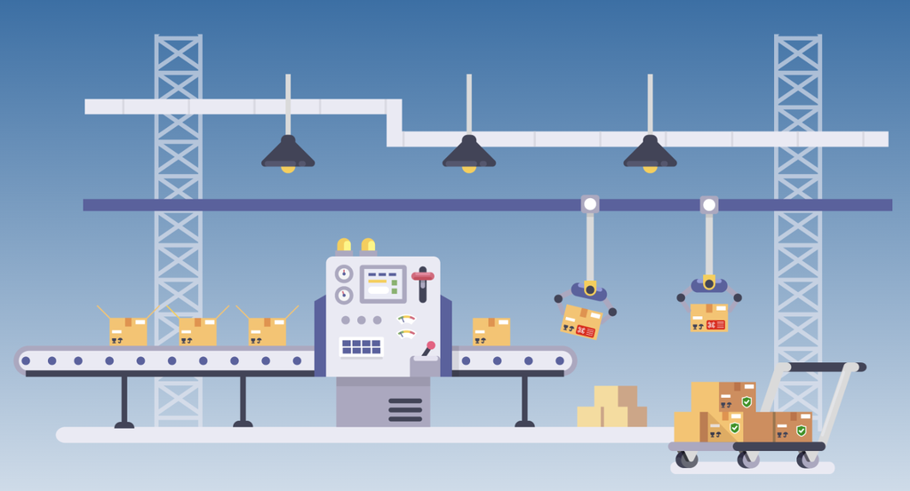

## Excercises (revisited)

```r
diamonds_cut <- group_by(diamonds, cut)
summarize(diamonds_cut,
          mean_price = mean(price),
          median_price = median(price))
```

```
## # A tibble: 5 × 3
##   cut       mean_price median_price
##   <ord>          <dbl>        <dbl>
## 1 Fair           4359.        3282
## 2 Good           3929.        3050.
## 3 Very Good      3982.        2648
## 4 Premium        4584.        3185
## 5 Ideal          3458.        1810
```

## Exercise (revisited): use pipe function %>%

```r
diamonds %>%
  group_by(cut) %>%
  summarize(mean_price = mean(price),
            median_price = median(price))
```

```
## # A tibble: 5 × 3
##   cut       mean_price median_price
##   <ord>          <dbl>        <dbl>
## 1 Fair           4359.        3282
## 2 Good           3929.        3050.
## 3 Very Good      3982.        2648
## 4 Premium        4584.        3185
## 5 Ideal          3458.        1810
```

## Exercises: multiple transformations

```r
diamonds %>%
  select(cut, color, clarity, carat) %>%
  filter(clarity == "IF" & cut == "Ideal")
```

```
## # A tibble: 1,212 × 4
##    cut   color clarity carat
##    <ord> <ord> <ord>   <dbl>
##  1 Ideal F     IF       0.52
##  2 Ideal G     IF       0.55
##  3 Ideal G     IF       0.64
##  4 Ideal G     IF       0.61
##  5 Ideal F     IF       0.53
##  6 Ideal G     IF       0.62
##  7 Ideal G     IF       0.62
##  8 Ideal I     IF       0.71
##  9 Ideal I     IF       0.74
## 10 Ideal G     IF       0.64
## # ℹ 1,202 more rows
```

## Exercises: plotting

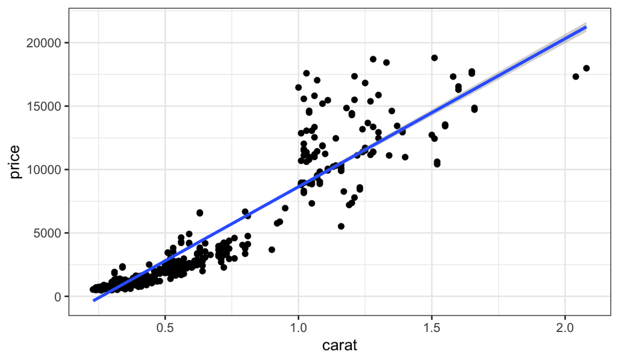

```r
diamonds %>%
  filter(clarity == "IF" & cut == "Ideal") %>%
  ggplot(aes(x = carat, y = price)) +
  geom_point() +
  geom_smooth(method = "lm")+
  theme_bw()
```

## Other useful functions

- merge data sets: `inner_join()`, `left_join()`, `right_join()`, `anti_join()`, etc.
- `pivot_longer()` and `pivor_wider()`: converts data from wide to long and vice versa.

## Resources of data wrangling

- Ref: https://www.tidyverse.org/
- Cheat sheet: https://rstudio.github.io/cheatsheets/data-transformation.pdf
- R for Data Science: https://r4ds.hadley.nz/

## HPC

HPC (high performance computing) aggregates the resources from individual computers (nodes) into a cluster that works together to perform advanced, specialized computing jobs.

[figure not shown]

## HPC at USC

CARC: Center for Advanced Research Computing

- https://www.carc.usc.edu/
- https://www.carc.usc.edu/user-information/user-guides/hpc-basics/discovery-resources

Provides workshop and weekly office hours

## CARC computing resource

- Login node (Head node)
- Compute node wired together (~500), including CPU and GPU nodes
- Disk array and file servers
- Slurm job scheduler
- Discovery (free) and Endeavour (paid by PI) cluster

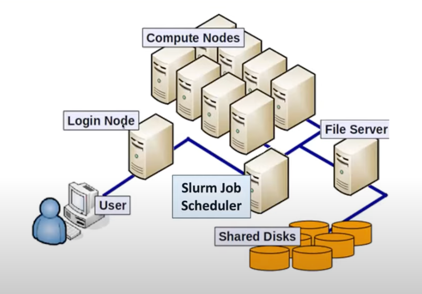

## Accessing CARC system

PI can add a member to a project

Username: USC NetID (eg. zzhang39)

## Network requirment

- On campus: connect to “USC secure wireless”
- Off campus: get your device connected to USC VPN

## Connecting to Discovery login node

Method 1: Secure shell command line interface (highly recommended)

- On Mac: Terminal
- On Windows: OpenSSH, Putty, etc

```bash
ssh <username>@discovery.usc.edu
```

## Connecting to Discovery login node

Method 2: Use OnDemand interface

https://www.carc.usc.edu/user-guides/carc-ondemand/ondemand-overview

## Navigate the system

private to yourself:

- home directory: /home1/<username>
- scratch directories: /scratch1/<username>

private to a group:

- /project/<pi_username_id>

## Commonly used commands

```bash
pwd # print working dir
cd  # change dir

ls -lh # list files
less   # go through a file forward and backward
cat    # print to screen
head   # print the top 10 rows
tail   # print the last 10 rows

mkdir  # create a new dir
touch  # create an empty file
mv     # move file to another dir; or change file/dir name
cp     # copy files
rm     # remove files; WARNING: be careful with this

man    # look at manuals for each command
```

## Request interactive node

In shell:

```bash
salloc --time=1:00:00 --mem=8Gb
```

*Please DO NOT run heavy task on login node!*

## Load R

```bash
module purge # unload any current loaded modules

# load required modules and R (4.3.2 version)
module load gcc/11.3.0
module load openblas/0.3.20
module load r/4.3.2

# check R
which R
```

## Trouble shooting with R package installation

- https://hpc-discourse.usc.edu/t/r-package-installation-guide/653

Thanks to Xinran Wang for suggesting this!

## Run R interactively

Go to shell for demo.

## Run R through slurm jobs

Tutorials:

https://www-dev.carc.usc.edu/user-information/user-guides/hpc-basics/slurm-templates

```bash
Rscript load_data.R
```